# Hypothesis_Testing

Tanishq

2025-05-02

```r
library(tidyverse)
library(infer)
sat <- read_csv("SAT.csv")
head(sat)
```

```
## # A tibble: 6 × 6
##   DBN    `School Name`             Number of Test Taker…¹ Critical Reading Mea…²
##   <chr>  <chr>                                      <dbl>                  <dbl>
## 1 01M292 Henry Street School for …                     31                    391
## 2 01M448 University Neighborhood …                     60                    394
## 3 01M450 East Side Community High…                     69                    418
## 4 01M458 SATELLITE ACADEMY FORSYT…                     26                    385
## 5 01M509 CMSP HIGH SCHOOL                              NA                     NA
## 6 01M515 Lower East Side Preparat…                    154                    314
## # ℹ abbreviated names: ¹`Number of Test Takers`, ²`Critical Reading Mean`
## # ℹ 2 more variables: `Mathematics Mean` <dbl>, `Writing Mean` <dbl>
```

# Data Cleaning

```r
sat <- sat |> rename(reading = `Critical Reading Mean`,
                     math = `Mathematics Mean`,
                     writing = `Writing Mean`) |>
  filter(!is.na(reading), !is.na(math), !is.na(writing))

sat_aov <- sat |> select(reading,
                         math,
                         writing) |>
  pivot_longer(cols = c(reading,
                        math,
                        writing),
               names_to = "subject",
               values_to = "score")

  head(sat_aov)
```

```
## # A tibble: 6 × 2
##   subject score
##   <chr>   <dbl>
## 1 reading   391
## 2 math      425
## 3 writing   385
## 4 reading   394
## 5 math      419
## 6 writing   387
```

```r
sat_math_reading <- sat |>
  select(math, reading) |>
  mutate(diff = math - reading)

sat_math_writing <- sat |>
  select(math, writing) |>
  mutate(diff = math - writing)

sat_writing_reading <- sat |>
  select(writing, reading) |>
  mutate(diff = writing - reading)
```

# Anova Test

Significance level $\alpha = 0.05$ for all the tests.

$H_{0}:$ The mean SAT score is same across all the subject.

$\mu_{math} = \mu_{reading} = \mu_{writing}$

$H_{a}:$ At least one of the mean SAT score is different from others.

At least one $\mu$ differs among math, reading and writing

```r
anova_result <- aov(formula = score~subject, data = sat_aov)
summary(anova_result)
```

```
##               Df  Sum Sq Mean Sq F value  Pr(>F)
## subject        2   45153   22576   6.278 0.00194 **
## Residuals   1155 4153518    3596
## ---
## Signif. codes:  0 '***' 0.001 '**' 0.01 '*' 0.05 '.' 0.1 ' ' 1
```

# Anova Conclusion

since p-value $= 0.00194 < 0.05$ We Reject Null Hypothesis.

At least one subject’s mean SAT score (Math, Reading, Writing) is significantly different from others.

# Pairwise T-Test

why? to find out which subject’s mean SAT score differs from other.

```r
pairwise.t.test(sat_aov$score,
                sat_aov$subject,
                p.adjust.method = "bonferroni")
```

```
##
##  Pairwise comparisons using t tests with pooled SD
##
## data:  sat_aov$score and sat_aov$subject
##
##         math   reading
## reading 0.1332 -
## writing 0.0013 0.3866
##
## P value adjustment method: bonferroni
```

# Pairwise T-Test Conclusion

| Comparison | Adjusted p-value | Result |
| --- | --- | --- |
| Math vs Reading | 0.1332 | No Significant Difference |
| Math vs Writing | 0.0013 | Significant Difference |
| Writing vs Reading | 0.3866 | No Significant Difference |

Only Math and Writing shows significant difference in mean SAT score.

# Box Plot

To visualize difference between mean SAT scores across each subject.

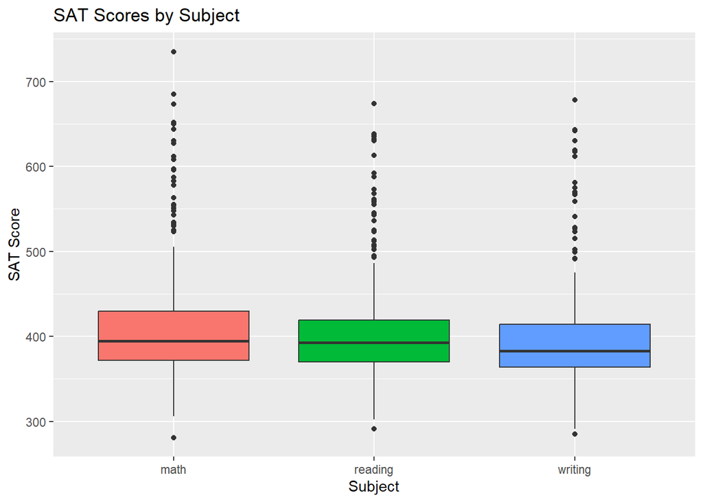

```r
ggplot(sat_aov, aes(x = subject, y = score, fill = subject)) +
  geom_boxplot() +
  labs(title = "SAT Scores by Subject",
       x = "Subject",
       y = "SAT Score") +
  theme(legend.position = "none")
```

# Paired T-Test

## Math vs Writing

$H_{0}$: There is no difference in Mathematics mean score and Writing Mean score across all schools

$H_{a}$: There is significant difference in Mathematics mean score and Writing Mean score across all schools

$H_{0}:$ diff $= 0$

$H_{a}:$ diff $\not= 0$

### Method 1: Using t.test (Assumes CLT condition are satisfied)

```r
t.test(x = sat_math_writing$math,
       y = sat_math_writing$writing,
       alternative = "two.sided",
       paired = TRUE)
```

```
##
##  Paired t-test
##
## data:  sat_math_writing$math and sat_math_writing$writing
## t = 10.71, df = 385, p-value < 2.2e-16
## alternative hypothesis: true mean difference is not equal to 0
## 95 percent confidence interval:
##  12.44724 18.04498
## sample estimates:
## mean difference
##        15.24611
```

### Method 2: Using Bootstrap re-samples

```r
null_dist <- sat_math_writing |>
  specify(response = diff) |>
  hypothesize(null = "point", mu = 0) |>
  generate(reps = 1000, type = "bootstrap") |>
  calculate(stat = "mean")

obs_stat <- mean(sat_math_writing$diff)

get_p_value(null_dist, obs_stat, direction = "two.sided")
```

```
## # A tibble: 1 × 1
##   p_value
##     <dbl>
## 1       0
```

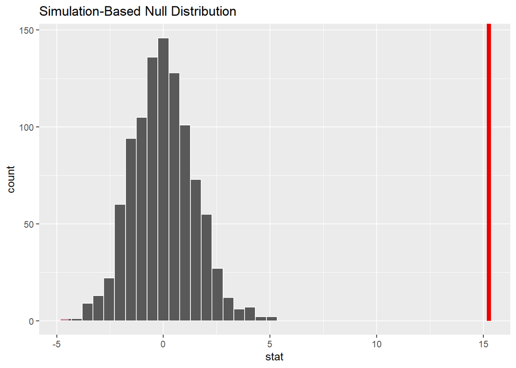

```r
visualize(null_dist, bins = 20) +
  shade_p_value(obs_stat = obs_stat, direction = "two.sided")
```

## Conclusion (Math vs Writing)

The both the method above show that p value is less than the significance level therefore, rejecting the null hypothesis and concluding that difference between math and writing mean score across school is significant

## Math vs Reading

$H_{0}$: There is no difference in Mathematics mean score and Reading Mean score across all schools

$H_{a}$: There is significant difference in Mathematics mean score and Reading Mean score across all schools

$H_{0}:$ diff $= 0$

$H_{a}:$ diff $\not= 0$

### Method 1: Using t.test (Assumes CLT condition are satisfied)

```r
t.test(x = sat_math_reading$math,
       y = sat_math_reading$reading,
       alternative = "two.sided",
       paired = TRUE)
```

```
##
##  Paired t-test
##
## data:  sat_math_reading$math and sat_math_reading$reading
## t = 5.8569, df = 385, p-value = 1.012e-08
## alternative hypothesis: true mean difference is not equal to 0
## 95 percent confidence interval:
##   5.770501 11.602556
## sample estimates:
## mean difference
##        8.686528
```

### Method 2: Using Bootstrap re-samples

```r
null_dist <- sat_math_reading |>
  specify(response = diff) |>
  hypothesize(null = "point", mu = 0) |>
  generate(reps = 1000, type = "bootstrap") |>
  calculate(stat = "mean")

obs_stat <- mean(sat_math_reading$diff)

get_p_value(null_dist, obs_stat, direction = "two.sided")
```

```
## # A tibble: 1 × 1
##   p_value
##     <dbl>
## 1       0
```

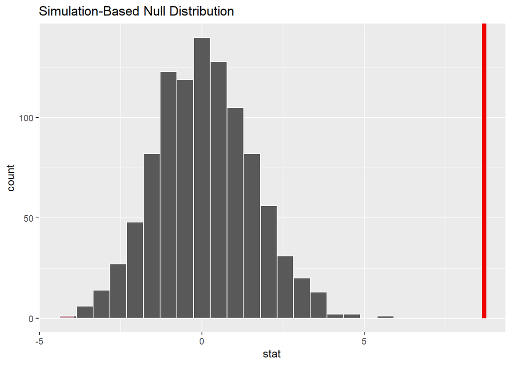

```r
visualize(null_dist, bins = 20) +
  shade_p_value(obs_stat = obs_stat, direction = "two.sided")
```

## Conclusion (Math vs Reading)

The both the method above show that p value is less than the significance level therefore, rejecting the null hypothesis and concluding that difference between math and reading mean score across school is significant

## Writing vs Reading

$H_{0}$: There is no difference in Writing mean score and Reading Mean score across all schools

$H_{a}$: There is significant difference in Writing mean score and Reading Mean score across all schools

$H_{0}:$ diff $= 0$

$H_{a}:$ diff $\not= 0$

### Method 1: Using t.test (Assumes CLT condition are satisfied)

```r
t.test(x = sat_writing_reading$writing,
       y = sat_writing_reading$reading,
       alternative = "two.sided",
       paired = TRUE)
```

```
##
##  Paired t-test
##
## data:  sat_writing_reading$writing and sat_writing_reading$reading
## t = -10.791, df = 385, p-value < 2.2e-16
## alternative hypothesis: true mean difference is not equal to 0
## 95 percent confidence interval:
##  -7.754799 -5.364372
## sample estimates:
## mean difference
##       -6.559585
```

### Method 2: Using Bootstrap re-samples

```r
null_dist <- sat_writing_reading |>
  specify(response = diff) |>
  hypothesize(null = "point", mu = 0) |>
  generate(reps = 1000, type = "bootstrap") |>
  calculate(stat = "mean")

obs_stat <- mean(sat_writing_reading$diff)

get_p_value(null_dist, obs_stat, direction = "two.sided")
```

```
## # A tibble: 1 × 1
##   p_value
##     <dbl>
## 1       0
```

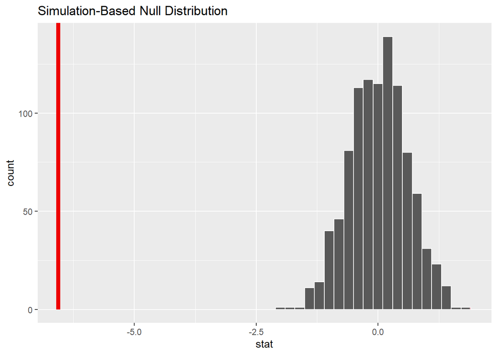

```r
visualize(null_dist, bins = 20) +
  shade_p_value(obs_stat = obs_stat, direction = "two.sided")
```

## Conclusion (Writing vs Reading)

The both the method above show that p value is less than the significance level therefore, rejecting the null hypothesis and concluding that difference between writing and reading mean score across school is significant.

# Independent T-Test (Welch Two Sample T-Test)

## Math vs Writing

$H_0: \mu_{math} - \mu_{writing} = 0$

$H_a: \mu_{math} - \mu_{writing} \not= 0$

```r
t.test(x = sat_math_writing$math,
       y = sat_math_writing$writing,
       alternative = "two.sided",
       paired = FALSE)
```

```
##
##  Welch Two Sample t-test
##
## data:  sat_math_writing$math and sat_math_writing$writing
## t = 3.4449, df = 759.54, p-value = 0.0006025
## alternative hypothesis: true difference in means is not equal to 0
## 95 percent confidence interval:
##   6.558154 23.934074
## sample estimates:
## mean of x mean of y
##  412.9352  397.6891
```

## Math vs Reading

$H_0: \mu_{math} - \mu_{reading} = 0$

$H_a: \mu_{math} - \mu_{reading} \not= 0$

```r
t.test(x = sat_math_reading$math,
       y = sat_math_reading$reading,
       alternative = "two.sided",
       paired = FALSE)
```

```
##
##  Welch Two Sample t-test
##
## data:  sat_math_reading$math and sat_math_reading$reading
## t = 1.977, df = 756.49, p-value = 0.0484
## alternative hypothesis: true difference in means is not equal to 0
## 95 percent confidence interval:
##   0.06108013 17.31197686
## sample estimates:
## mean of x mean of y
##  412.9352  404.2487
```

## Conclusion (Math vs Reading)

p-values $= 0.0484 < 0.05$. Reject Null Hypothesis. Mean SAT score in math and reading have significant difference.

Note: This result is different than pairwise t-test performed before why?

The result differs due to usage of Bonferroni correction made in pairwise t-test to reduce false positives.

current p_value $= 0.0484$

adjusted p_value $=$ current p_value $\cdot 3$ $= 0.1452$ which is closer to p_value in pairwise t-test for math vs reading, which was $0.1332$

## Writing vs Reading

$H_0: \mu_{writing} - \mu_{reading} = 0$

$H_a: \mu_{writing} - \mu_{reading} \not= 0$

```r
t.test(x = sat_writing_reading$writing,
       y = sat_writing_reading$reading,
       alternative = "two.sided",
       paired = FALSE)
```

```
##
##  Welch Two Sample t-test
##
## data:  sat_writing_reading$writing and sat_writing_reading$reading
## t = -1.5906, df = 769.79, p-value = 0.1121
## alternative hypothesis: true difference in means is not equal to 0
## 95 percent confidence interval:
##  -14.65501   1.53584
## sample estimates:
## mean of x mean of y
##  397.6891  404.2487
```

## Conclusion (Writing vs Reading)

p-values $= 0.1121 > 0.05$. Accept Null Hypothesis. Mean SAT score in writing and reading does not have significant difference.